# ARACNe_analysis

Amy Hicks

15/12/2021

The basis of Algorithm for the Reconstruction of Accurate Cellular Networks with Adaptive Partitioning (ARACNe-AP) is introduced [here](https://github.com/califano-lab/ARACNe-AP), written in Java. This set of instructions is adapted from `UsingAracne.Rmd` provided by Juan Botia, which allows it to instead be used from within R. The data used was obtained from primary gene co-expression networks from [CoExp (Garcia-Ruiz et al., 2021)](https://www.ncbi.nlm.nih.gov/pmc/articles/PMC7943635/).

# 1. Setting up ARACNe

Local functions are described in more detail in the `UsingAracne` markdown.

```r
# Create fucntions for file paths
gjp = function(){ return("/usr/bin/java")}
gsp = function(){ return(file.path(here::here("docs", "ARACNe/")))}
# Create the function for running ARACNe
runAracneMIJava = function(exp.file,
                           out.folder,
                           tfs.file,
                           p.value,
                           seed,
                           calc.threshold,
                           tissue,
                           which.one){
    command = paste0(gjp()," -jar ",gsp(),"/Aracne.jar -e ",exp.file," -o ", out.folder,
            " --tfs ",tfs.file," --pvalue ",p.value," --seed ")
    if(calc.threshold){
        init.command = paste0(command,seed[1]," --calculateThreshold")
        cat("Running command\"",init.command,"\"\n")
        system(init.command)
    }

    if(length(seed) == 1){
        command = paste0(command,seed," --nobootstrap")
        cat("Running command\"",command,"\"\n")
        system(command)
        out.file = paste0(out.folder,"/",tissue,".",which.one,".aracnet.txt")
        command = paste0("mv ",out.folder,"/nobootstrap_network.txt ",out.file)
        cat("Running command\"",command,"\"\n")
        system(command)

        return(read.delim(out.file))
    }

    for(single.seed in seed){
        local.command = paste0(command,single.seed)
        cat("Running command\"",local.command,"\"\n")
        system(local.command)
    }
    command = paste0(gjp()," -jar ",gsp(),"/Aracne.jar -o ", out.folder,
            " --consolidate")
    cat("Running command\"",command,"\"\n")
    system(command)
    file.remove(list.files(path=out.folder,pattern="bootstrapNetwork_*",full.names=T))
    out.file = paste0(exp.file,".aracnet.txt")
    command = paste0("mv ",out.folder,"/network.txt ",
            out.file)
    cat("Running command\"",command,"\"\n")
    system(command)
    return(read.delim(out.file))

}
```

# 2. File formatting

NSL genes were selected as the **regulator** genes.

## 2.1. Regulator file

```r
# Initialise the datasets to use
CoExpGTEx::initDb(mandatory = T)
CoExp10UKBEC::initDb(mandatory = T)
# Open ensembl
ensembl = useMart(biomart = "ENSEMBL_MART_ENSEMBL", dataset = "hsapiens_gene_ensembl")
# Load gene list (see Genelists.R for details)
NSL_list <- read.delim(file.path(here::here("data","Gene_lists", "NSL_list.txt")))
# Load PD lists
PD_mendelian_list <- read.delim(file.path(here::here("data", "Gene_lists", "PD_mendelian_list.txt")))
PD_mendelian_ENSG <- as.character(PD_mendelian_list$Ensembl_ID)
PD_GWAS_list <- read.delim(file.path(here::here("data", "Gene_lists", "PD_GWAS_list.txt")))
PD_GWAS_ENSG <- as.character(PD_GWAS_list$Ensembl_ID)
```

```r
# Add UKBEC gene names
NSL_list$UKBEC <- as.character(NSL_list$Gene_symbol)
NSL_list$UKBEC[NSL_list$UKBEC=="KANSL1"] <- "KIAA1267"
NSL_list$UKBEC[NSL_list$UKBEC=="KAT8"] <- "MYST1"
NSL_list$UKBEC[NSL_list$UKBEC=="KANSL2"] <- "C12orf41"
NSL_list$UKBEC[NSL_list$UKBEC=="KANSL3"] <- "KIAA1310"
# Load UKBEC tID conversion table copied from CoExpNets source files
trans.table <- read.csv(file.path(here::here("data", "CoExp_source", "annot_19K.csv")))
trans.table <- as.data.frame(trans.table)
trans.table$XtID <- as.character(trans.table$XtID)
trans.table$Gene_Symbol <- as.character(trans.table$Gene_Symbol)
# Add column with UKBEC tIDs
NSL_list$UKBEC_id <- as.character(NSL_list$UKBEC)
for (i in trans.table$Gene_Symbol) {
  loc <- match(i, trans.table$Gene_Symbol)
  NSL_list$UKBEC_id[NSL_list$UKBEC_id == i] <- trans.table$XtID[loc]
}
```

```r
# Add modules and module memberships for GTEx
NSL_list <- dplyr::arrange(NSL_list, Gene_symbol)
gt_MM <- CoExpNets::getMM(net = NULL, expr.data.file = NULL, tissue = "FCortex", which.one = "gtexv6", genes = NSL_list$Ensembl_ID) %>%
  dplyr::arrange(name)
NSL_list$GTEx_mod <- gt_MM$module
NSL_list$GTEx_MM <- gt_MM$mm
# Add modules and module memberships for UKBEC
uk_MM <- CoExpNets::reportOnGenes(tissue = "FCTX", genes = NSL_list$UKBEC, which.one = "10UKBEC")
uk_MM <- uk_MM$report
NSL_list$UKBEC_mod <- as.character(NSL_list$UKBEC)
NSL_list$UKBEC_MM <- as.character(NSL_list$UKBEC)
for (i in uk_MM$gene) {
  loc <- match(i, uk_MM$gene)
  NSL_list$UKBEC_MM[NSL_list$UKBEC_MM == i] <- uk_MM$mm[loc]
}
for (i in uk_MM$gene) {
  loc <- match(i, uk_MM$gene)
  NSL_list$UKBEC_mod[NSL_list$UKBEC_mod == i] <- uk_MM$module[loc]
}
```

## 2.2. Expression files

### GTEx

One set of genes was selected as the **regulated** genes from the **GTEx frontal cortex** coexpression network: all genes from `red` and `darkred` modules.

```r
# Load frontal cortex expression values
GTExnet <- CoExpNets::getExprDataFromTissue(tissue = "FCortex", which.one = "gtexv6")
# Format expression file correctly
GTExnet <- t(GTExnet)
GTExnet <- as.data.frame(GTExnet)
GTExnet <- rownames_to_column(GTExnet, var = "gene")
# Get list of genes in red/darkred modules
red_genes <- CoExpNets::getGenesFromModule(tissue = "FCortex", which.one = "gtexv6", module = "red")
darkred_genes <- CoExpNets::getGenesFromModule(tissue = "FCortex", which.one = "gtexv6", module = "darkred")
gt_genes <- append(red_genes, darkred_genes)
# Filter expression values for red/darkred modules
gt_expr <- dplyr::filter(GTExnet, gene %in% gt_genes)
# Save expression files
write.table(gt_expr, "gt_expr.txt", sep="\t", row.names=FALSE)
# Remove " from files
```

### UKBEC

One set of genes was selected as the **regulated** genes from the **UKBEC frontal cortex** coexpression network: all genes from `black` module.

```r
# Load frontal cortex expression values
UKnet <- CoExpNets::getExprDataFromTissue(tissue = "FCTX", which.one = "10UKBEC")
# Format expression file correctly
UKnet <- t(UKnet)
UKnet <- as.data.frame(UKnet)
UKnet <- rownames_to_column(UKnet, var = "gene")
# Get list of genes in black module
black_genes <- CoExpNets::getGenesFromModule(tissue = "FCTX", which.one = "10UKBEC", module = "black")
# Filter expression values for black modules
uk_expr <- dplyr::filter(UKnet, gene %in% black_genes)
# Save expression files
write.table(uk_expr, "uk_expr.txt", sep="\t", row.names=FALSE)
# Remove " from files
```

# 3. Running analysis

## GTEx

The `runAracneMIJava` function was run on the regulated gene set, with the recommended `p.value` and bootstrapped seed of `1:10000`.

```r
# Run function
gt_aracne <- runAracneMIJava(exp.file = file.path(here::here("data", "ARACNe", "gtex_expr.txt")),
                              out.folder = file.path(here::here("data", "ARACNe/")),
                              tfs.file =file.path(here::here("data", "Gene_lists", "NSL_ENSG.txt")),
                              p.value = "1E-8",
                              seed = 1:10000,
                              calc.threshold = TRUE,
                              tissue = "FCortex",
                              which.one = "GTEx_10000")
```

```r
# Load output file
gt_aracne <- read.delim(file.path(here::here("data", "ARACNe", "gtex_expr.txt.aracnet.txt")))
```

## UKBEC

Again the `runAracneMIJava` function was run on the regulated gene set, with the recommended `p.value` and bootstrapped seed of `1:10000`.

```r
# Run function on red/darkred module genes
uk_aracne <- runAracneMIJava(exp.file = file.path(here::here("data", "ARACNe", "ukbec_expr.txt")),
                               out.folder = file.path(here::here("data", "ARACNe/")),
                               tfs.file = file.path(here::here("data", "Gene_lists", "NSL_ukbec.txt")),
                               p.value = "1E-8",
                               seed = 1:10000,
                               calc.threshold = TRUE,
                               tissue = "FCTX",
                               which.one = "UKBEC_10000")
```

```r
# Load output file
uk_aracne <- read.delim(file.path(here::here("data", "ARACNe", "ukbec_expr.txt.aracnet.txt")))
```

# 4. GTEx results

## 4.1. Characteristics

### Individual regulons

The function returned a total of **5959** possible regulatory relationships involving the NSL genes within the `red` and `darkred` modules.

```r
# Add MI quantile to result
gt_aracne$MI_quantile <- ecdf(gt_aracne$MI)(gt_aracne$MI)
# Add regulator gene symbols to result
gt_aracne$Regulator_gene<- as.character(gt_aracne$Regulator)
gt_aracne$Target <- as.character(gt_aracne$Target)
for (i in NSL_list$Ensembl_ID) {
  loc <- match(i, NSL_list$Ensembl_ID)
  gt_aracne$Regulator_gene[gt_aracne$Regulator_gene == i] <- NSL_list$Gene_symbol[loc]
}
```

```r
# Count number of hits for each NSL gene
gt_aracne_summ <- dplyr::count(gt_aracne, Regulator_gene)
gt_aracne_summ$Module <- as.character(gt_aracne_summ$Regulator_gene)
gt_aracne_summ$MM <- as.character(gt_aracne_summ$Regulator_gene)
# Add modules and memberships
for (i in NSL_list$Gene_symbol) {
  loc <- match(i, NSL_list$Gene_symbol)
  gt_aracne_summ$Module[gt_aracne_summ$Module == i] <- NSL_list$GTEx_mod[loc]
}
for (i in NSL_list$Gene_symbol) {
  loc <- match(i, NSL_list$Gene_symbol)
  gt_aracne_summ$MM[gt_aracne_summ$MM == i] <- NSL_list$GTEx_MM[loc]
}
gt_aracne_summ$MM <- as.numeric(gt_aracne_summ$MM)
names(gt_aracne_summ)[names(gt_aracne_summ)=="n"] <- "Number_targets"
gt_aracne_summ <- gt_aracne_summ[,c(1,3,4,2)] %>%
  dplyr::arrange(Number_targets)
# Total number of targets for each NSL gene regulator
gt_aracne_summ
```

| Regulator_gene | Module | MM | Number_targets |
| --- | --- | --- | --- |
| KANSL1 | red | 0.8117476 | 491 |
| OGT | red | 0.7795841 | 617 |
| HCFC1 | red | 0.7745495 | 704 |
| KAT8 | darkred | 0.7190373 | 775 |
| MCRS1 | darkred | 0.8493827 | 1584 |
| WDR5 | red | 0.9035292 | 1788 |

Of interest were the NSL genes predicted to **regulate eachother**.

```r
# Filter for NSL genes as targets
gt_NSL <- dplyr::filter(gt_aracne, Target %in% NSL_list$Ensembl_ID)
# Add target gene symbols
gt_NSL$Target_gene <- as.character(gt_NSL$Target)
for (i in NSL_list$Ensembl_ID) {
  loc <- match(i, NSL_list$Ensembl_ID)
  gt_NSL$Target_gene[gt_NSL$Target_gene == i] <- NSL_list$Gene_symbol[loc]
}
# Display all NSL relationships
dplyr::arrange(gt_NSL[, c(6,7,4,3,5)], desc(MI_quantile))
```

| Regulator_gene | Target_gene | pvalue | MI | MI_quantile |
| --- | --- | --- | --- | --- |
| WDR5 | MCRS1 | 0 | 0.5030834 | 0.8164121 |
| MCRS1 | WDR5 | 0 | 0.5029100 | 0.8159087 |
| KANSL1 | WDR5 | 0 | 0.4654812 | 0.6843430 |
| WDR5 | KANSL1 | 0 | 0.4651671 | 0.6831683 |
| HCFC1 | WDR5 | 0 | 0.4429124 | 0.5844940 |
| WDR5 | HCFC1 | 0 | 0.4428973 | 0.5843262 |
| KANSL1 | HCFC1 | 0 | 0.4240262 | 0.4848129 |
| HCFC1 | KANSL1 | 0 | 0.4239582 | 0.4841416 |
| KANSL1 | OGT | 0 | 0.4139722 | 0.4296023 |
| OGT | KANSL1 | 0 | 0.4135896 | 0.4277563 |

[output cut: 4 more lines]

The **overlap** in regulons of the NSL genes was also examined.

```r
# Remove unique targets
gt_aracne_overlap <- gt_aracne[gt_aracne$Target %in% gt_aracne$Target[duplicated(gt_aracne$Target)],]
```

The total number of genes appearing in **>1 regulon** is **1850**.

```r
# Count number of shared targets for each NSL gene
gt_aracne_summ2 <- dplyr::count(gt_aracne_overlap, Regulator_gene)
names(gt_aracne_summ2)[names(gt_aracne_summ2)=="n"] <- "Shared_targets"
gt_aracne_summ2 <- dplyr::left_join(gt_aracne_summ, gt_aracne_summ2, by = "Regulator_gene")
gt_aracne_summ2[,c(1,4,5)]
```

| Regulator_gene | Number_targets | Shared_targets |
| --- | --- | --- |
| KANSL1 | 491 | 478 |
| OGT | 617 | 566 |
| HCFC1 | 704 | 671 |
| KAT8 | 775 | 715 |
| MCRS1 | 1584 | 1288 |
| WDR5 | 1788 | 1673 |

The overlap in regulons was tested for significance using a **Fishers exact test**. If the overlap p-value **<0.05**, this meant these genes shared a significant amount of their targets, suggesting one may be regulating the other.

```r
# Make summary dataframe
gt_aracne_nsltargets <- as.data.frame(matrix(nrow = 6, ncol = 6))
colnames(gt_aracne_nsltargets) <- gt_aracne_summ$Regulator_gene
rownames(gt_aracne_nsltargets) <- gt_aracne_summ$Regulator_gene
# Perform Fishers test on NSL genes
source(file.path(here::here("scripts", "ARACNe_functions.R")))
for (i in colnames(gt_aracne_nsltargets)) {
  for (j in rownames(gt_aracne_nsltargets)) {
    pval <- fishers_test_targets(i, j, gt_aracne)
    pval <- p.adjust(pval, method = "fdr")
    gt_aracne_nsltargets[i,j] <- pval
  }
}
```

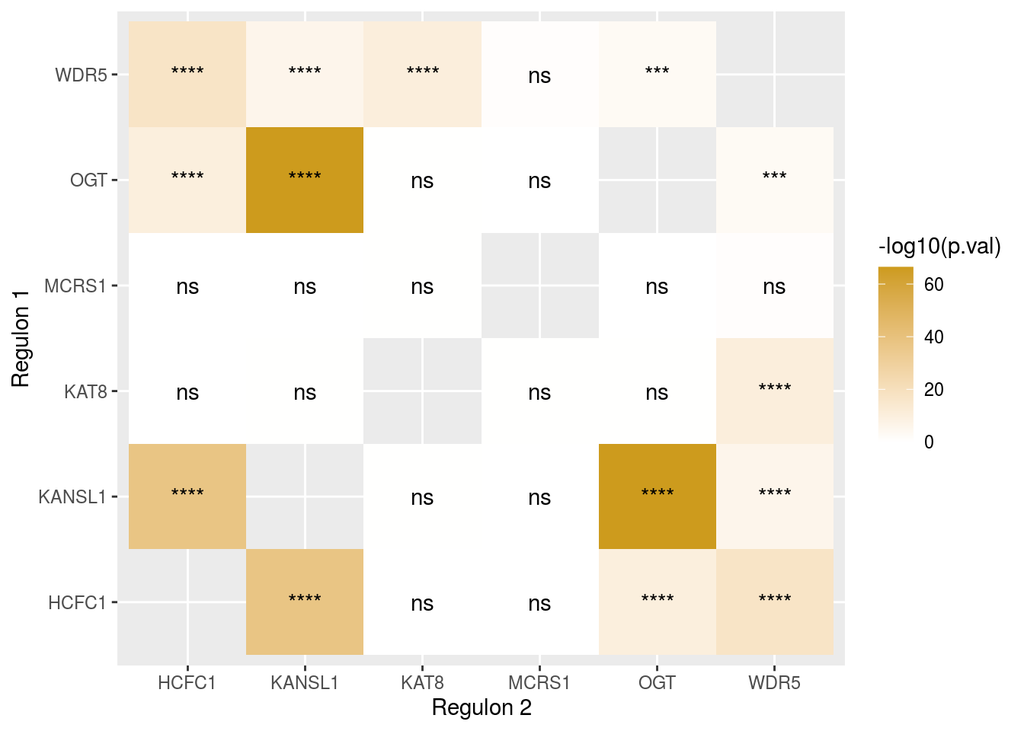

```r
# Format for figure
gt_aracne_nsltargets <- rownames_to_column(gt_aracne_nsltargets, var = "Regulon_1")
gt_aracne_regulon <- tidyr::gather(gt_aracne_nsltargets, "Regulon_2", "p.val", -Regulon_1)
gt_aracne_regulon$p.val <- as.numeric(gt_aracne_regulon$p.val)
gt_aracne_regulon <- dplyr::filter(gt_aracne_regulon, Regulon_1 != Regulon_2)
gt_aracne_regulon$`-log10(p.val)` <- -log10(gt_aracne_regulon$p.val)
# Plot
source(file.path(here::here("scripts", "CoExp_functions.R")))
ggplot(gt_aracne_regulon, aes(Regulon_1, Regulon_2)) +
  geom_tile(aes(fill = `-log10(p.val)`)) +
  geom_text(aes(label = signif.num(p.val))) +
  scale_fill_gradient(low = "white", high = "goldenrod3") +
  labs(y = "Regulon 1", x = "Regulon 2")
```

### NSL regulon

Genes appearing in 3 or more of the regulons were focused on, termed the **NSL regulon**.

```r
# Filter results for genes in 3+ regulons
gt_regs_count <- gt_aracne %>%
  dplyr::count(Target)
gt_regs <- dplyr::left_join(gt_aracne, gt_regs_count, by = "Target")
gt_3regs <- gt_regs %>%
  dplyr::filter(n >=3)
```

## 4.2. Gene set enrichment analysis

### Individual regulons

The appearance of each PD gene list in the regulons were tested for significance using a **Fishers exact test**. If the overlap p-value **<0.05**, this meant these gene list appeared as targets for these two genes more often than would be expected by chance.

```r
# Make summary dataframe
gt_NSLresults_test <- as.data.frame(matrix(nrow = 2, ncol = 6))
colnames(gt_NSLresults_test) <- c("KAT8", "KANSL1", "OGT", "MCRS1", "HCFC1", "WDR5")
rownames(gt_NSLresults_test) <- c("PD_mendelian", "PD_GWAS")
# Perform Fishers tests for all columns
gt_NSLresults_test[1,1] <- fishers_test_lists(c("KAT8"), PD_mendelian_ENSG, gt_aracne)
gt_NSLresults_test[1,2] <- fishers_test_lists(c("KANSL1"), PD_mendelian_ENSG, gt_aracne)
gt_NSLresults_test[1,3] <- fishers_test_lists(c("OGT"), PD_mendelian_ENSG, gt_aracne)
gt_NSLresults_test[1,4] <- fishers_test_lists(c("MCRS1"), PD_mendelian_ENSG, gt_aracne)
gt_NSLresults_test[1,5] <- fishers_test_lists(c("HCFC1"), PD_mendelian_ENSG, gt_aracne)
gt_NSLresults_test[1,6] <- fishers_test_lists(c("WDR5"), PD_mendelian_ENSG, gt_aracne)
gt_NSLresults_test[2,1] <- fishers_test_lists(c("KAT8"), PD_GWAS_ENSG, gt_aracne)
gt_NSLresults_test[2,2] <- fishers_test_lists(c("KANSL1"), PD_GWAS_ENSG, gt_aracne)
gt_NSLresults_test[2,3] <- fishers_test_lists(c("OGT"), PD_GWAS_ENSG, gt_aracne)
gt_NSLresults_test[2,4] <- fishers_test_lists(c("MCRS1"), PD_GWAS_ENSG, gt_aracne)
gt_NSLresults_test[2,5] <- fishers_test_lists(c("HCFC1"), PD_GWAS_ENSG, gt_aracne)
gt_NSLresults_test[2,6] <- fishers_test_lists(c("WDR5"), PD_GWAS_ENSG, gt_aracne)
# Show results
gt_NSLresults_test
```

|  | KAT8 | KANSL1 | OGT | MCRS1 | HCFC1 | WDR5 |
| --- | --- | --- | --- | --- | --- | --- |
| PD_mendelian | 0.9018672 | 0.3521685 | 0.8296195 | 0.8883066 | 0.2392708 | 0.9944171 |
| PD_GWAS | 0.6764964 | 0.3000510 | 0.8571616 | 0.5385695 | 0.3826182 | 0.4201539 |

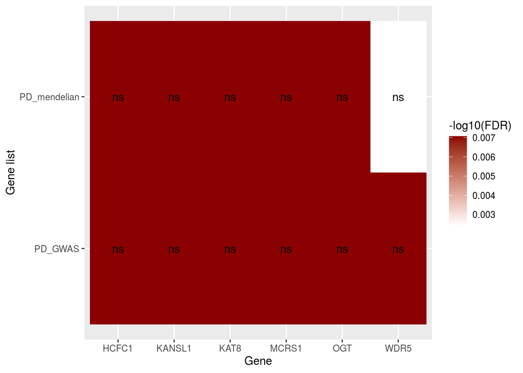

```r
# Prep for figure
fig_gt <- rownames_to_column(gt_NSLresults_test, var = "Gene_list")
fig_gt <- tidyr::gather(fig_gt, "Gene", "p.val", 2:7)
fig_gt$Gene_list <- as.character(fig_gt$Gene_list)
fig_gt$Gene <- as.character(fig_gt$Gene)
fig_gt$p.val <- as.numeric(fig_gt$p.val)
fig_gt$FDR <- p.adjust(fig_gt$p.val, method = "fdr")
fig_gt$`-log10(FDR)` <- -log10(fig_gt$FDR)
# Plot
ggplot(fig_gt, aes(Gene, Gene_list)) +
  geom_tile(aes(fill = `-log10(FDR)`)) +
  geom_text(aes(label = signif.num(FDR))) +
  scale_fill_gradient(low = "white", high = "red4") +
  labs(y = "Gene list", x = "Gene")
```

### NSL regulon

The NSL regulon was also filtered for genes linked to Mendelian PD.

```r
# Filter
gt_3regs_mendPD <- gt_3regs %>%
  dplyr::filter(Target %in% PD_mendelian_list$Ensembl_ID) %>%
  dplyr::mutate(Target_gene = as.character(Target))
# Add target gene symbols
for (i in PD_mendelian_list$Ensembl_ID) {
  loc <- match(i, PD_mendelian_list$Ensembl_ID)
  gt_3regs_mendPD$Target_gene[gt_3regs_mendPD$Target_gene == i] <- PD_mendelian_list$Gene_symbol[loc]
}
# Show results
gt_3regs_mendPD %>%
  dplyr::select(Regulator_gene, Target_gene, MI, MI_quantile)
```

| Regulator_gene | Target_gene | MI | MI_quantile |
| --- | --- | --- | --- |
| HCFC1 | ATXN2 | 0.4405449 | 0.5715724 |
| WDR5 | ATXN2 | 0.4825764 | 0.7484477 |
| HCFC1 | PLA2G6 | 0.3605180 | 0.1498574 |
| KANSL1 | PLA2G6 | 0.3534008 | 0.1181406 |
| MCRS1 | PLA2G6 | 0.3645467 | 0.1693237 |
| OGT | ATXN2 | 0.4681725 | 0.6939084 |
| KANSL1 | ATXN2 | 0.5509444 | 0.9129048 |

2 different genes associated with Mendelian PD were present in the NSL regulon. This was tested for significance using a **Fishers exact test**.

```r
fishers_test_lists2(c(3,4,5,6), c(PD_mendelian_list$Ensembl_ID), gt_regs)
```

```
## [1] 0.8432522
```

The NSL regulon was also filtered for genes linked to sporadic PD.

```r
# Filter
gt_3regs_gwasPD <- gt_3regs %>%
  dplyr::filter(Target %in% PD_GWAS_list$Ensembl_ID) %>%
  dplyr::mutate(Target_gene = as.character(Target))
# Add target gene symbols
for (i in PD_GWAS_list$Ensembl_ID) {
  loc <- match(i, PD_GWAS_list$Ensembl_ID)
  gt_3regs_gwasPD$Target_gene[gt_3regs_gwasPD$Target_gene == i] <- PD_GWAS_list$Gene_symbol[loc]
}
# Show results
gt_3regs_gwasPD %>%
  dplyr::select(Regulator_gene, Target_gene, MI, MI_quantile)
```

| Regulator_gene | Target_gene | MI | MI_quantile |
| --- | --- | --- | --- |
| OGT | QRICH1 | 0.4229142 | 0.4791072 |
| WDR5 | DGKQ | 0.5693498 | 0.9360631 |
| HCFC1 | SH2B1 | 0.4661854 | 0.6860211 |
| WDR5 | PGS1 | 0.4993365 | 0.8051687 |
| KAT8 | SETD1A | 0.3878833 | 0.2936734 |
| WDR5 | BIN3 | 0.4843595 | 0.7541534 |
| KAT8 | BIN3 | 0.4187339 | 0.4567881 |
| HCFC1 | CCAR2 | 0.4769649 | 0.7289814 |
| WDR5 | SETD1A | 0.5144753 | 0.8449404 |
| MCRS1 | SH2B1 | 0.4819887 | 0.7457627 |

[output cut: 33 more lines]

12 different genes associated with sporadic PD were present in the NSL regulon. This was tested for significance using a **Fishers exact test**.

```r
fishers_test_lists2(c(3,4,5,6), c(PD_GWAS_list$Ensembl_ID), gt_regs)
```

```
## [1] 0.6188506
```

## 4.3. GO term enrichment analysis

### Individual regulons

Each regulon was examined for the **enrichment** of different gene ontology terms using `gProfiler`.

```r
# Filter KANSL1 results
gt_K1 <- dplyr::filter(gt_aracne, Regulator_gene == "KANSL1")
gt_K1 <- as.character(gt_K1$Target)
# Filter KAT8 results
gt_K8 <- dplyr::filter(gt_aracne, Regulator_gene == "KAT8")
gt_K8 <- as.character(gt_K8$Target)
# Filter HCFC1 results
gt_HC <- dplyr::filter(gt_aracne, Regulator_gene == "HCFC1")
gt_HC <- as.character(gt_HC$Target)
# Filter OGT results
gt_OGT <- dplyr::filter(gt_aracne, Regulator_gene == "OGT")
gt_OGT <- as.character(gt_OGT$Target)
# Filter MCRS1 results
gt_MC <- dplyr::filter(gt_aracne, Regulator_gene == "MCRS1")
gt_MC <- as.character(gt_MC$Target)
# Filter WDR5 results
gt_WD <- dplyr::filter(gt_aracne, Regulator_gene == "WDR5")
gt_WD <- as.character(gt_WD$Target)
# Use gprofiler to search list of regulons
regs_gt_gprof <- gost(query = list("KANSL1" = gt_K1, "KAT8" = gt_K8, "OGT" = gt_OGT, "MCRS1" = gt_MC, "HCFC1" = gt_HC, "WDR5" = gt_WD))
regs_gt_gprof <- as.data.frame(regs_gt_gprof$result)
regs_gt_gprof <- apply(regs_gt_gprof,2,as.character)
write.csv(regs_gt_gprof, file.path(here::here("data", "ARACNe", "regs_gtex_gprof.csv")), row.names = FALSE)
```

First **GO: molecular function**:

```r
regs_gt_gprof <- read.csv(file.path(here::here("data", "ARACNe", "regs_gtex_gprof.csv")))
# Molecular function
regs_gt_MF <- regs_gt_gprof %>%
  dplyr::filter(source == "GO:MF") %>%
  dplyr::select(query, p_value, term_id, source, term_name)
# Rename columns
names(regs_gt_MF)[names(regs_gt_MF)=="query"] <- "gene_list"
names(regs_gt_MF)[names(regs_gt_MF)=="term_id"] <- "go_id"
names(regs_gt_MF)[names(regs_gt_MF)=="source"] <- "go_type"
names(regs_gt_MF)[names(regs_gt_MF)=="term_name"] <- "go_term"
# FDR correct p values
regs_gt_MF$p_value <- as.numeric(regs_gt_MF$p_value)
regs_gt_MF$FDR <- p.adjust(regs_gt_MF$p_value, method="fdr")
# GO reduce all terms to parent terms
regs_gt_MF$go_type <- "MF"
regs_gt_MF_GO <- go_reduce(pathway_df = regs_gt_MF, threshold = 0.7, scores = NULL)
```

Second **GO: cellular component**

```r
# Cellular component
regs_gt_CC <- regs_gt_gprof %>%
  dplyr::filter(source == "GO:CC") %>%
  dplyr::select(query, p_value, term_id, source, term_name)
# Rename columns
names(regs_gt_CC)[names(regs_gt_CC)=="query"] <- "gene_list"
names(regs_gt_CC)[names(regs_gt_CC)=="term_id"] <- "go_id"
names(regs_gt_CC)[names(regs_gt_CC)=="source"] <- "go_type"
names(regs_gt_CC)[names(regs_gt_CC)=="term_name"] <- "go_term"
# FDR correct p values
regs_gt_CC$p_value <- as.numeric(regs_gt_CC$p_value)
regs_gt_CC$FDR <- p.adjust(regs_gt_CC$p_value, method="fdr")
# GO reduce all terms to parent terms
regs_gt_CC$go_type <- "CC"
regs_gt_CC_GO <- go_reduce(pathway_df = regs_gt_CC, threshold = 0.7, scores = NULL)
```

Third **GO: biological process**:

```r
# Biological process
regs_gt_BP <- regs_gt_gprof %>%
  dplyr::filter(source == "GO:BP") %>%
  dplyr::select(query, p_value, term_id, source, term_name)
# Rename columns
names(regs_gt_BP)[names(regs_gt_BP)=="query"] <- "gene_list"
names(regs_gt_BP)[names(regs_gt_BP)=="term_id"] <- "go_id"
names(regs_gt_BP)[names(regs_gt_BP)=="source"] <- "go_type"
names(regs_gt_BP)[names(regs_gt_BP)=="term_name"] <- "go_term"
# FDR correct p values
regs_gt_BP$p_value <- as.numeric(regs_gt_BP$p_value)
regs_gt_BP$FDR <- p.adjust(regs_gt_BP$p_value, method="fdr")
# GO reduce all terms to parent terms
regs_gt_BP$go_type <- "BP"
regs_gt_BP_GO <- go_reduce(pathway_df = regs_gt_BP, threshold = 0.7, scores = NULL)
```

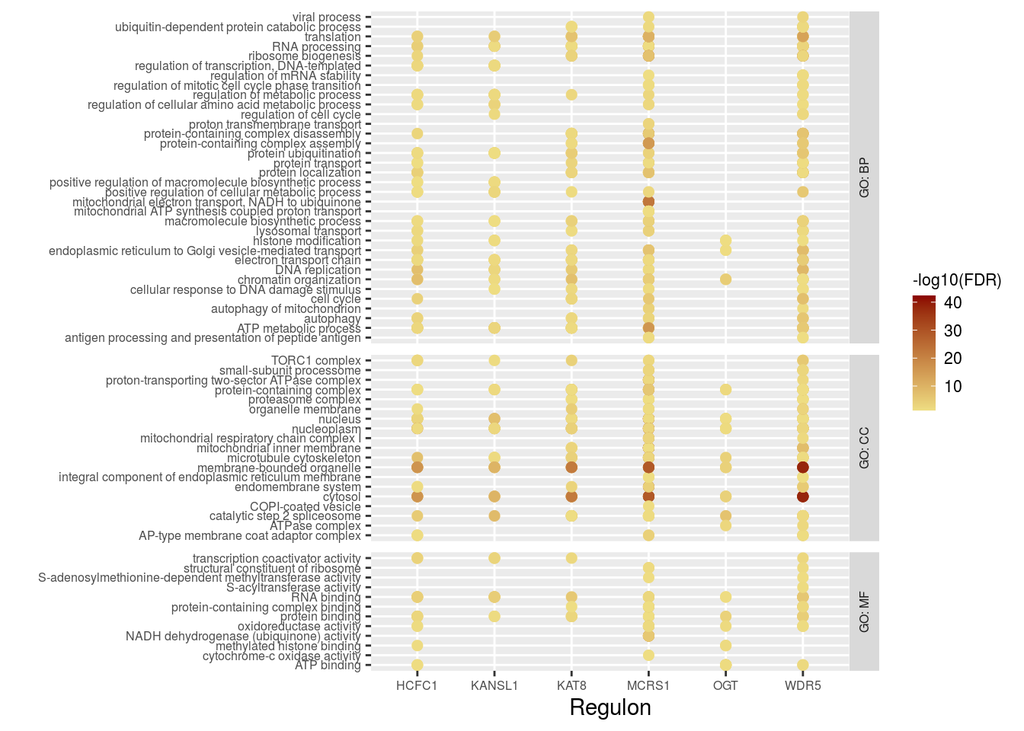

```r
# Bind together and format
regs_gt_GO <- dplyr::bind_rows(regs_gt_BP_GO, regs_gt_CC_GO, regs_gt_MF_GO)
regs_gt_GO <- dplyr::filter(regs_gt_GO, parent_term != "NA")
regs_gt_GO$go_type[regs_gt_GO$go_type=="BP"] <- "GO: BP"
regs_gt_GO$go_type[regs_gt_GO$go_type=="MF"] <- "GO: MF"
regs_gt_GO$go_type[regs_gt_GO$go_type=="CC"] <- "GO: CC"
# GO figure
ggplot2::ggplot(regs_gt_GO, aes(x = gene_list, y = parent_term)) +
  geom_point(size = 2, aes(colour = -log10(`FDR`))) +
  scale_color_continuous(low = "lightgoldenrod", high = "red4") +
  facet_grid(go_type ~., scales = "free", space = "free") +
  labs(x = "Regulon", y = "") +
  theme(
    axis.text = element_text(size = 6),
    strip.text.y = element_text(angle = 90, size = 6),
    legend.title = element_text(size = 8),
    legend.text = element_text(size = 8),
    legend.key.size = unit(4, "mm"))
```

### NSL regulon

The NSL regulon was was analysed in a similar way to the individual regulons.

```r
# Filter results for genes in 3+ regulons
gt_regs_count <- gt_aracne %>%
  dplyr::count(Target)
gt_regs <- dplyr::left_join(gt_aracne, gt_regs_count, by = "Target")
gt_3regs <- gt_regs %>%
  dplyr::filter(n >=3)
```

```r
# Run gprofiler
gt_3regs_gprof <- gprofiler2::gost(query = gt_3regs$Target)
gt_3regs_gprof <- as.data.frame(gt_3regs_gprof$result)
gt_3regs_gprof <- as.data.frame(apply(gt_3regs_gprof, 2, as.character))
gt_3regs_gprof$FDR <- p.adjust(gt_3regs_gprof$p_value, method = "fdr")
# save
write.csv(gt_3regs_gprof, file.path(here::here("data", "ARACNe", "3regs_gtex_gprof.csv")), row.names = FALSE)
```

```r
# Load
gt_3regs_gprof <- read.csv(file.path(here::here("data", "ARACNe", "3regs_gtex_gprof.csv")))
# Add intersection ratio
gt_3regs_gprof <- gt_3regs_gprof %>%
  dplyr::mutate(Ratio = intersection_size/term_size)
```

First **molecular function**:

```r
# Molecular function
gt_3regs_MF <- gt_3regs_gprof %>%
  dplyr::filter(source == "GO:MF" & FDR <= 0.05) %>%
  dplyr::select(query, p_value, term_id, source, term_name, Ratio)
# Rename columns
names(gt_3regs_MF)[names(gt_3regs_MF)=="query"] <- "gene_list"
names(gt_3regs_MF)[names(gt_3regs_MF)=="term_id"] <- "go_id"
names(gt_3regs_MF)[names(gt_3regs_MF)=="source"] <- "go_type"
names(gt_3regs_MF)[names(gt_3regs_MF)=="term_name"] <- "go_term"
# FDR correct p values
gt_3regs_MF$p_value <- as.numeric(gt_3regs_MF$p_value)
gt_3regs_MF$FDR <- p.adjust(gt_3regs_MF$p_value, method="fdr")
# GO reduce all terms to parent terms
gt_3regs_MF$go_type <- "MF"
gt_3regs_MF_GO <- go_reduce(pathway_df = gt_3regs_MF, threshold = 0.7, scores = NULL)
```

Second **cellular component**

```r
# Cellular component
gt_3regs_CC <- gt_3regs_gprof %>%
  dplyr::filter(source == "GO:CC" & FDR <= 0.05) %>%
  dplyr::select(query, p_value, term_id, source, term_name, Ratio)
# Rename columns
names(gt_3regs_CC)[names(gt_3regs_CC)=="query"] <- "gene_list"
names(gt_3regs_CC)[names(gt_3regs_CC)=="term_id"] <- "go_id"
names(gt_3regs_CC)[names(gt_3regs_CC)=="source"] <- "go_type"
names(gt_3regs_CC)[names(gt_3regs_CC)=="term_name"] <- "go_term"
# FDR correct p values
gt_3regs_CC$p_value <- as.numeric(gt_3regs_CC$p_value)
gt_3regs_CC$FDR <- p.adjust(gt_3regs_CC$p_value, method="fdr")
# GO reduce all terms to parent terms
gt_3regs_CC$go_type <- "CC"
gt_3regs_CC_GO <- go_reduce(pathway_df = gt_3regs_CC, threshold = 0.7, scores = NULL)
```

Third **biological process**:

```r
# Biological process
gt_3regs_BP <- gt_3regs_gprof %>%
  dplyr::filter(source == "GO:BP" & FDR <= 0.05) %>%
  dplyr::select(query, p_value, term_id, source, term_name, Ratio)
# Rename columns
names(gt_3regs_BP)[names(gt_3regs_BP)=="query"] <- "gene_list"
names(gt_3regs_BP)[names(gt_3regs_BP)=="term_id"] <- "go_id"
names(gt_3regs_BP)[names(gt_3regs_BP)=="source"] <- "go_type"
names(gt_3regs_BP)[names(gt_3regs_BP)=="term_name"] <- "go_term"
# FDR correct p values
gt_3regs_BP$p_value <- as.numeric(gt_3regs_BP$p_value)
gt_3regs_BP$FDR <- p.adjust(gt_3regs_BP$p_value, method="fdr")
# GO reduce all terms to parent terms
gt_3regs_BP$go_type <- "BP"
gt_3regs_BP_GO <- go_reduce(pathway_df = gt_3regs_BP, threshold = 0.7, scores = NULL)
```

```r
# Bind together
gt_3regs_GO <- dplyr::bind_rows(gt_3regs_BP_GO, gt_3regs_CC_GO, gt_3regs_MF_GO)
# Format
gt_3regs_GO <- dplyr::filter(gt_3regs_GO, parent_term != "NA")
gt_3regs_GO$go_type[gt_3regs_GO$go_type=="BP"] <- "GO: BP"
gt_3regs_GO$go_type[gt_3regs_GO$go_type=="MF"] <- "GO: MF"
gt_3regs_GO$go_type[gt_3regs_GO$go_type=="CC"] <- "GO: CC"
# Add reduced terms count and mean intersection ratio
gt_3regs_GO_count <- gt_3regs_GO %>%
  dplyr::count(parent_term)
gt_3regs_GO <- gt_3regs_GO %>%
  dplyr::left_join(gt_3regs_GO_count, by = "parent_term") %>%
  dplyr::group_by(parent_term) %>%
  dplyr::mutate(mean_ratio = mean(Ratio))
```

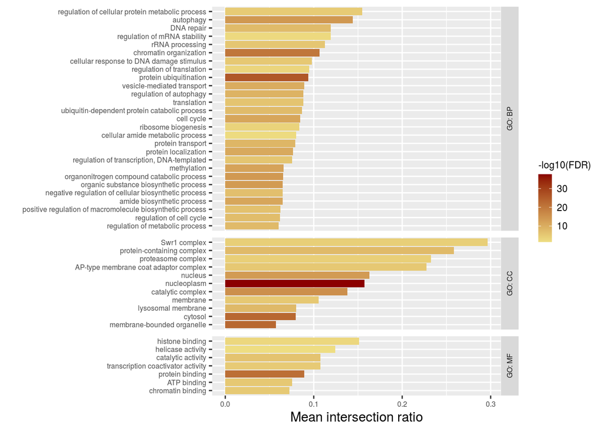

```r
# Plot on bar chart
gt_3regs_GO %>%
  dplyr::arrange(FDR) %>%
  dplyr::distinct(parent_term, .keep_all = TRUE) %>%
  ggplot2::ggplot(aes(x = mean_ratio,
                      y = reorder(parent_term, mean_ratio),
                      fill = -log10(`FDR`))) +
  geom_col() +
  scale_fill_gradient(high = "red4", low = "Lightgoldenrod") +
  facet_grid(go_type ~., scales = "free", space = "free") +
  labs(y = "", x = "Mean intersection ratio") +
  theme(
    axis.text = element_text(size = 6),
    strip.text.y = element_text(angle = 90, size = 6),
    legend.title = element_text(size = 8),
    legend.text = element_text(size = 8),
    legend.key.size = unit(4, "mm"))
```

## 4.4. KEGG/reactome term entichment

### Individual regulons

Each regulon was also examined for the **enrichment** of different KEGG and reactome terms using `gProfiler`. These terms were then compared to a list of **46** terms **"nominated as potentially linked to PD risk through common genetic variation"** obtained from [Bandres-Ciga et al., 2020](https://www.ncbi.nlm.nih.gov/pmc/articles/PMC8096770/). Firstly, as this list only contained terms from KEGG, Reactome and Pathway Interaction Database sources, the `gProfiler` results for each regulon were filtered for these sources and formatted.

```r
# Filter for KEGG and REACTOME terms
regs_gt_KGRE <- regs_gt_gprof %>%
  dplyr::filter(source %in% c("KEGG", "REAC"))
# Rename columns
names(regs_gt_KGRE)[names(regs_gt_KGRE)=="query"] <- "gene_list"
names(regs_gt_KGRE)[names(regs_gt_KGRE)=="term_id"] <- "go_id"
names(regs_gt_KGRE)[names(regs_gt_KGRE)=="source"] <- "go_type"
names(regs_gt_KGRE)[names(regs_gt_KGRE)=="term_name"] <- "go_term"
# FDR correct p values
regs_gt_KGRE$p_value <- as.numeric(regs_gt_KGRE$p_value)
regs_gt_KGRE$FDR <- p.adjust(regs_gt_KGRE$p_value, method="fdr")
# Format list for comparing terms
regs_gt_KGRE$col <- 1:nrow(regs_gt_KGRE)
regs_gt_KGRE_comp <- dplyr::select(regs_gt_KGRE, col, go_term)
```

The table of **PD-linked terms** was then uploaded and formatted.

```r
# Upload table from paper
pd_replication_tab1 <- read.csv(file.path(here::here("data", "pd_replication_tab1.txt")))
# Format table from paper
pd_replication_tab1$Set <- as.character(pd_replication_tab1$Gene_set)
pd_replication_tab1$Set <- gsub(" (", "-", pd_replication_tab1$Set, fixed = TRUE)
pd_replication_tab1$Set <- gsub(")", "", pd_replication_tab1$Set, fixed = TRUE)
pd_replication_tab1 <- tidyr::separate(pd_replication_tab1, Set, c("Term", "Database"), "-")
# Format for comparison
pd_r <- pd_replication_tab1 %>%
  dplyr::select(Term)
pd_r$col <- 1:nrow(pd_r)
```

As the two lists of terms contained several of the same terms that were formatted slightly differently, they first needed to be checked for consistency and unified. This was done using `tidystringdist`.

```r
# Combine lists
list_compare_gt <- dplyr::union(regs_gt_KGRE_comp$go_term, pd_r$Term)
list_compare_gt <- unique(list_compare_gt)
# Find similar but not identical matches
comparison_gt <- tidy_comb_all(list_compare_gt)
comparison_gt <- tidy_stringdist(comparison_gt)
comparison_gt <- dplyr::arrange(comparison_gt, V1)
comparison_gt_1 <- comparison_gt %>%
             dplyr::filter(osa < 10)
# Go through by eye and remove rows with differing terms
comparison_gt_1 <- comparison_gt_1 %>%
  dplyr::slice(4,11,14,38,40,59)
# Pick a format for the similar terms and replace in lists consistently
regs_gt_KGRE$go_term[regs_gt_KGRE$go_term=="Asparagine N linked glycosylation"] <- "Asparagine N-linked glycosylation"
regs_gt_KGRE$go_term[regs_gt_KGRE$go_term=="COPI mediated anterograde transport"] <- "COPI-mediated anterograde transport"
regs_gt_KGRE$go_term[regs_gt_KGRE$go_term=="ER to GOLGI Anterograde Transport"] <- "ER to Golgi Anterograde Transport"
regs_gt_KGRE$go_term[regs_gt_KGRE$go_term=="Parkinson disease"] <- "Parkinsons disease"
regs_gt_KGRE$go_term[regs_gt_KGRE$go_term=="Post translational protein modification"] <- "Post-translational protein modification"
regs_gt_KGRE$go_term[regs_gt_KGRE$go_term=="Transport to the GOLGI and subsequent modification"] <- "Transport to the Golgi and subsequent modification"
pd_replication_tab1$Term[pd_replication_tab1$Term=="Asparagine N linked glycosylation"] <- "Asparagine N-linked glycosylation"
pd_replication_tab1$Term[pd_replication_tab1$Term=="COPI mediated anterograde transport"] <- "COPI-mediated anterograde transport"
pd_replication_tab1$Term[pd_replication_tab1$Term=="ER to GOLGI Anterograde Transport"] <- "ER to Golgi Anterograde Transport"
pd_replication_tab1$Term[pd_replication_tab1$Term=="Parkinson disease"] <- "Parkinsons disease"
pd_replication_tab1$Term[pd_replication_tab1$Term=="Post translational protein modification"] <- "Post-translational protein modification"
pd_replication_tab1$Term[pd_replication_tab1$Term=="Transport to the GOLGI and subsequent modification"] <- "Transport to the Golgi and subsequent modification"
```

The list of terms enriched for each NSL regulon was then filtered for those linked to PD by [Bandres-Ciga et al., 2020](https://www.ncbi.nlm.nih.gov/pmc/articles/PMC8096770/).

```r
# Filter ARACNe list for paper list
all_terms_gt <- regs_gt_KGRE %>%
  dplyr::filter(go_term %in% pd_replication_tab1$Term) %>%
  dplyr::select(gene_list, go_term, p_value, FDR, go_type) %>%
  dplyr::arrange(go_term)
all_terms_gt$go_type[all_terms_gt$go_type== "REAC"] <- "REACTOME"
```

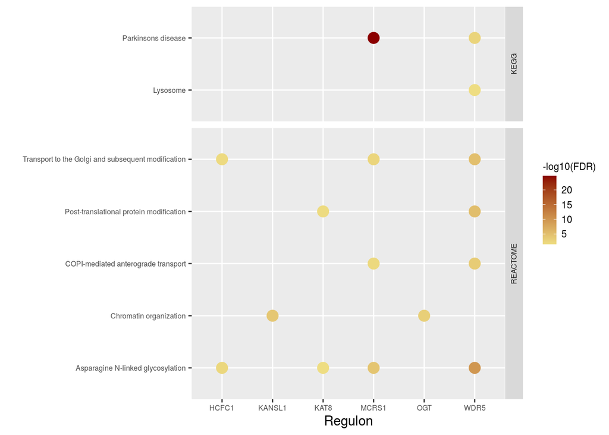

```r
ggplot2::ggplot(all_terms_gt, aes(x = gene_list, y = go_term)) +
  geom_point(size = 4, aes(colour = -log10(`FDR`))) +
  scale_color_continuous(low = "lightgoldenrod", high = "red4") +
  facet_grid(go_type ~., scales = "free", space = "free") +
  labs(x = "Regulon", y = "") +
  theme(
    axis.text = element_text(size = 6),
    strip.text.y = element_text(angle = 90, size = 6),
    legend.title = element_text(size = 8),
    legend.text = element_text(size = 8),
    legend.key.size = unit(4, "mm"))
```

### NSL regulon

The KEGG and reactome term enrichments for the list of genes appearing in **3 or more** regulons was also compared to this PD-linked list of terms.

```r
# Filter for KEGG and REACTOME terms
gt_3regs_KGRE <- gt_3regs_gprof %>%
  dplyr::filter(source %in% c("KEGG", "REAC"))
# Rename columns
names(gt_3regs_KGRE)[names(gt_3regs_KGRE)=="query"] <- "gene_list"
names(gt_3regs_KGRE)[names(gt_3regs_KGRE)=="term_id"] <- "go_id"
names(gt_3regs_KGRE)[names(gt_3regs_KGRE)=="source"] <- "go_type"
names(gt_3regs_KGRE)[names(gt_3regs_KGRE)=="term_name"] <- "go_term"
# FDR correct p values
gt_3regs_KGRE$p_value <- as.numeric(gt_3regs_KGRE$p_value)
gt_3regs_KGRE$FDR <- p.adjust(gt_3regs_KGRE$p_value, method="fdr")
# Format list for comparing terms
gt_3regs_KGRE$col <- 1:nrow(gt_3regs_KGRE)
gt_3regs_KGRE_comp <- dplyr::select(gt_3regs_KGRE, col, go_term)
# Combine lists
list_compare_gt_3regs <- dplyr::union(gt_3regs_KGRE_comp$go_term, pd_r$Term)
list_compare_gt_3regs <- unique(list_compare_gt_3regs)
# Find similar but not identical matches
comparison_gt_3regs <- tidy_comb_all(list_compare_gt_3regs)
comparison_gt_3regs <- tidy_stringdist(comparison_gt_3regs)
comparison_gt_3regs <- dplyr::arrange(as.data.frame(comparison_gt_3regs), V1)
comparison_gt_3regs_1 <- comparison_gt_3regs %>%
             dplyr::filter(osa < 10)
# Go through by eye and remove rows with differing terms
comparison_gt_3regs_1 <- comparison_gt_3regs_1 %>%
  dplyr::slice(-1,-2,-4,-6,-7,-8)
# All required text changes have already been made in previous check step
```

```r
# Filter ARACNe list for paper list
all_terms_gt_3regs <- gt_3regs_KGRE %>%
  dplyr::filter(go_term %in% pd_replication_tab1$Term) %>%
  dplyr::arrange(go_term) %>%
  dplyr::mutate(Ratio = intersection_size/term_size)
all_terms_gt_3regs$go_type[all_terms_gt_3regs$go_type== "REAC"] <- "REACTOME"
```

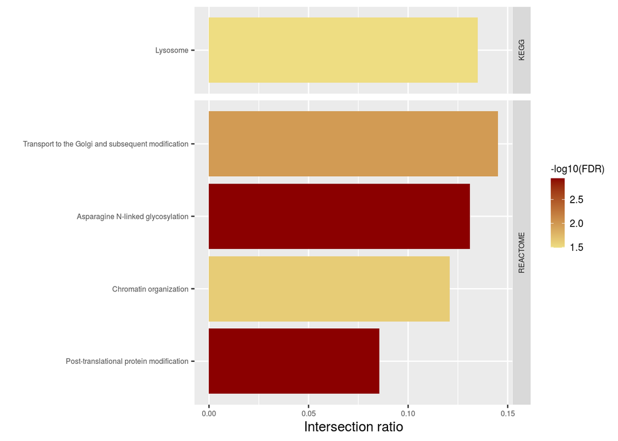

```r
# Plot as bar chart
all_terms_gt_3regs %>%
  dplyr::arrange(FDR) %>%
  ggplot2::ggplot(aes(x = Ratio,
                      y = reorder(go_term, Ratio),
                      fill = -log10(`FDR`))) +
  geom_col() +
  scale_fill_gradient(high = "red4", low = "Lightgoldenrod") +
  facet_grid(go_type ~., scales = "free", space = "free") +
  theme(strip.text.y = element_text(angle = 0))+
  labs(y = "", x = "Intersection ratio") +
  theme(
    axis.text = element_text(size = 6),
    strip.text.y = element_text(angle = 90, size = 6),
    legend.title = element_text(size = 8),
    legend.text = element_text(size = 8),
    legend.key.size = unit(4, "mm"))
```

# 5. UKBEC results

## 5.1. Characteristics

### Individual regulons

The function returned a total of **767** possible regulatory relationships involving the NSL genes within the `black` module.

```r
# Add MI quantile to result
uk_aracne$MI_quantile <- ecdf(uk_aracne$MI)(uk_aracne$MI)
# Add gene symbols to results table
uk_aracne$Regulator_gene <- as.character(uk_aracne$Regulator)
uk_aracne$Target_gene <- as.character(uk_aracne$Target)
for (i in NSL_list$UKBEC_id) {
  loc <- match(i, NSL_list$UKBEC_id)
  uk_aracne$Regulator_gene[uk_aracne$Regulator_gene == i] <- NSL_list$Gene_symbol[loc]
}
for (i in trans.table$XtID) {
  loc <- match(i, trans.table$XtID)
  uk_aracne$Target_gene[uk_aracne$Target_gene == i] <- trans.table$Gene_Symbol[loc]
}
```

```r
# Count number of hits for each NSL gene
uk_aracne_summ <- dplyr::count(uk_aracne, Regulator_gene)
uk_aracne_summ$Regulator_gene <- as.character(uk_aracne_summ$Regulator_gene)
uk_aracne_summ$Module <- uk_aracne_summ$Regulator_gene
uk_aracne_summ$MM <- uk_aracne_summ$Regulator_gene
# Add modules and memberships
for (i in NSL_list$Gene_symbol) {
  loc <- match(i, NSL_list$Gene_symbol)
  uk_aracne_summ$Module[uk_aracne_summ$Module == i] <- NSL_list$UKBEC_mod[loc]
}
for (i in NSL_list$Gene_symbol) {
  loc <- match(i, NSL_list$Gene_symbol)
  uk_aracne_summ$MM[uk_aracne_summ$MM == i] <- NSL_list$UKBEC_MM[loc]
}
uk_aracne_summ$MM <- as.numeric(uk_aracne_summ$MM)
names(uk_aracne_summ)[names(uk_aracne_summ)=="n"] <- "Number_targets"
uk_aracne_summ <- uk_aracne_summ %>%
  dplyr::arrange(Number_targets)
# Total number of targets for each NSL gene regulator
uk_aracne_summ[,c(1,3,4,2)]
```

| Regulator_gene | Module | MM | Number_targets |
| --- | --- | --- | --- |
| KAT8 | black | 0.4952 | 68 |
| MCRS1 | black | 0.5376 | 125 |
| KANSL1 | black | 0.6885 | 163 |
| HCFC1 | black | 0.8568 | 411 |

Of interest were the NSL genes predicted to **regulate eachother**.

```r
# Filter for NSL genes as targets
uk_aracne_NSL <- dplyr::filter(uk_aracne, Target_gene %in% NSL_list$UKBEC)
# Display all NSL relationships
dplyr::arrange(uk_aracne_NSL[, c(6,7,4,3,5)], desc(MI_quantile))
```

| Regulator_gene | Target_gene | pvalue | MI | MI_quantile |
| --- | --- | --- | --- | --- |

The **overlap** in the targets of NSL gene regulation was also examined.

```r
# Remove unique targets
uk_aracne_overlap <- uk_aracne[uk_aracne$Target %in% uk_aracne$Target[duplicated(uk_aracne$Target)],]
```

The total number of genes appearing as targets for >1 NSL gene is **213**.

```r
# Count number of shared targets for each NSL gene
uk_aracne_summ2 <- dplyr::count(uk_aracne_overlap, Regulator_gene)
names(uk_aracne_summ2)[names(uk_aracne_summ2)=="n"] <- "Shared_targets"
uk_aracne_summ2 <- dplyr::left_join(uk_aracne_summ, uk_aracne_summ2, by = "Regulator_gene")
uk_aracne_summ2[,c(1,2,5)]
```

| Regulator_gene | Number_targets | Shared_targets |
| --- | --- | --- |
| KAT8 | 68 | 57 |
| MCRS1 | 125 | 96 |
| KANSL1 | 163 | 120 |
| HCFC1 | 411 | 208 |

The overlap in targets between NSL genes was tested for significance using a **Fishers exact test**. If the overlap p-value **<0.05**, this meant these genes shared a significant amount of their targets, suggesting one may be regulating the other.

```r
# Make summary dataframe
uk_aracne_nsltargets <- as.data.frame(matrix(nrow = 4, ncol = 4))
colnames(uk_aracne_nsltargets) <- uk_aracne_summ$Regulator_gene
rownames(uk_aracne_nsltargets) <- uk_aracne_summ$Regulator_gene
# Perform Fishers test on NSL genes
for (i in colnames(uk_aracne_nsltargets)) {
  for (j in rownames(uk_aracne_nsltargets)) {
    pval <- fishers_test_targets(i, j, uk_aracne)
    pval <- format(round(pval, digits = 7), scientific = FALSE)
    uk_aracne_nsltargets[i,j] <- pval
  }
}
uk_aracne_nsltargets
```

|  | KAT8 | MCRS1 | KANSL1 | HCFC1 |
| --- | --- | --- | --- | --- |
| KAT8 | 0 | 0.4371727 | 0.9938182 | 0.5792442 |
| MCRS1 | 0.4371727 | 0 | 0.981265 | 0.9994509 |
| KANSL1 | 0.9938182 | 0.981265 | 0 | 0.9999976 |
| HCFC1 | 0.5792442 | 0.9994509 | 0.9999976 | 0 |

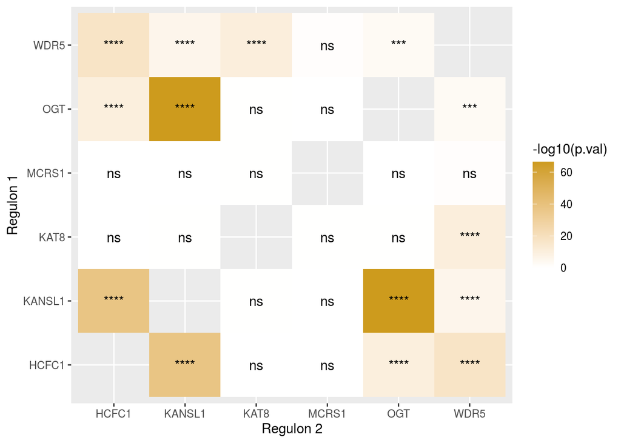

```r
# Format for figure
uk_aracne_nsltargets <- rownames_to_column(uk_aracne_nsltargets, var = "Regulon_1")
uk_aracne_regulon <- tidyr::gather(uk_aracne_nsltargets, "Regulon_2", "p.val", -Regulon_1)
uk_aracne_regulon$p.val <- as.numeric(uk_aracne_regulon$p.val)
uk_aracne_regulon <- dplyr::filter(uk_aracne_regulon, Regulon_1 != Regulon_2)
uk_aracne_regulon$`-log10(p.val)` <- -log10(uk_aracne_regulon$p.val)
# Plot
ggplot(gt_aracne_regulon, aes(Regulon_1, Regulon_2)) +
  geom_tile(aes(fill = `-log10(p.val)`)) +
  geom_text(aes(label = signif.num(p.val))) +
  scale_fill_gradient(low = "white", high = "goldenrod3") +
  labs(y = "Regulon 1", x = "Regulon 2")
```

### NSL regulon

Genes appearing in 3 or more of the regulons were focused on, termed the **NSL regulon**.

```r
# Filter results for genes in 3+ regulons
uk_regs_count <- uk_aracne %>%
  dplyr::count(Target)
uk_regs <- dplyr::left_join(uk_aracne, uk_regs_count, by = "Target")
uk_3regs <- uk_regs %>%
  dplyr::filter(n >=3)
```

## 5.2. Gene set enrichment analysis

### Individual regulons

```r
# Add columns with UKBEC IDs to gene list
PD_mendelian_list$UKBEC <- as.character(PD_mendelian_list$Gene_symbol)
PD_mendelian_list$UKBEC[PD_mendelian_list$UKBEC=="PRKN"] <- "PARK2"
PD_mendelian_list$UKBEC_id <- as.character(PD_mendelian_list$UKBEC)
for (i in trans.table$Gene_Symbol) {
  loc <- match(i, trans.table$Gene_Symbol)
  PD_mendelian_list$UKBEC_id[PD_mendelian_list$UKBEC_id == i] <- trans.table$XtID[loc]
}
# Black module results
uk_aracne_PDmend <- uk_aracne %>%
  dplyr::filter(Target_gene %in% PD_mendelian_list$UKBEC)
```

```r
# Add columns with UKBEC IDs to gene list
PD_GWAS_list$UKBEC <- as.character(PD_GWAS_list$Gene_symbol)
PD_GWAS_list$UKBEC[PD_GWAS_list$UKBEC=="CCAR2"] <- "KIAA1967"
PD_GWAS_list$UKBEC[PD_GWAS_list$UKBEC=="KLHL7-DT"] <- "KLHL7-AS1"
PD_GWAS_list$UKBEC[PD_GWAS_list$UKBEC=="RAB29"] <- "RAB7L1"
PD_GWAS_list$UKBEC[PD_GWAS_list$UKBEC=="RETREG3"] <- "FAM134C"
PD_GWAS_list$UKBEC[PD_GWAS_list$UKBEc=="SGF29"] <- "CCDC101"
PD_GWAS_list$UKBEC_id <- as.character(PD_GWAS_list$UKBEC)
for (i in trans.table$Gene_Symbol) {
  loc <- match(i, trans.table$Gene_Symbol)
  PD_GWAS_list$UKBEC_id[PD_GWAS_list$UKBEC_id == i] <- trans.table$XtID[loc]
}
# Black module results
uk_aracne_GWAS <- uk_aracne %>%
  dplyr::filter(Target_gene %in% PD_GWAS_list$UKBEC)
```

The appearance of each gene list in the results for the remaining NSL genes within the **black** module were tested for significance using a **Fishers exact test**. If the overlap p-value **<0.05**, this meant these gene list appeared as targets for these two genes more often than would be expected by chance.

```r
# Make summary dataframe
uk_aracne_NSLresults_test <- as.data.frame(matrix(nrow = 2, ncol = 4))
colnames(uk_aracne_NSLresults_test) <- c("KAT8", "KANSL1", "HCFC1", "MCRS1")
rownames(uk_aracne_NSLresults_test) <- c("PD_mendelian", "PD_GWAS")
# Perform Fishers tests for first 3 columns
uk_aracne_NSLresults_test[1,1] <- fishers_test_lists(c("KAT8"), PD_mendelian_list$UKBEC_id, uk_aracne)
uk_aracne_NSLresults_test[1,2] <- fishers_test_lists(c("KANSL1"), PD_mendelian_list$UKBEC_id, uk_aracne)
uk_aracne_NSLresults_test[1,3] <- fishers_test_lists(c("HCFC1"), PD_mendelian_list$UKBEC_id, uk_aracne)
uk_aracne_NSLresults_test[1,4] <- fishers_test_lists(c("MCRS1"), PD_mendelian_list$UKBEC_id, uk_aracne)
uk_aracne_NSLresults_test[2,1] <- fishers_test_lists(c("KAT8"), PD_GWAS_list$UKBEC_id, uk_aracne)
uk_aracne_NSLresults_test[2,2] <- fishers_test_lists(c("KANSL1"), PD_GWAS_list$UKBEC_id, uk_aracne)
uk_aracne_NSLresults_test[2,3] <- fishers_test_lists(c("HCFC1"), PD_GWAS_list$UKBEC_id, uk_aracne)
uk_aracne_NSLresults_test[2,4] <- fishers_test_lists(c("MCRS1"), PD_GWAS_list$UKBEC_id, uk_aracne)
# Show results
uk_aracne_NSLresults_test
```

|  | KAT8 | KANSL1 | HCFC1 | MCRS1 |
| --- | --- | --- | --- | --- |
| PD_mendelian | 1.0000000 | 0.7956349 | 0.8550561 | 1 |
| PD_GWAS | 0.5867773 | 0.6367945 | 0.7135926 | 1 |

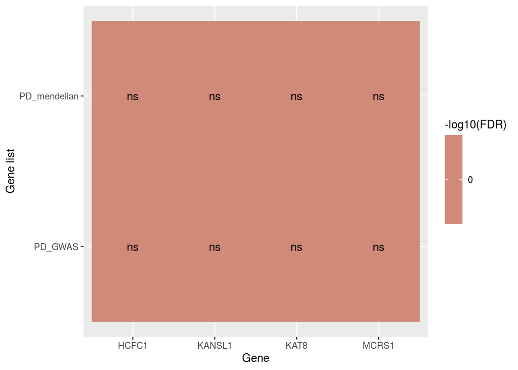

```r
# Prep for figure
fig_UK <- rownames_to_column(uk_aracne_NSLresults_test, var = "Gene_list")
fig_UK <- tidyr::gather(fig_UK, "Gene", "p.val", 2:5)
fig_UK$Gene_list <- as.character(fig_UK$Gene_list)
fig_UK$Gene <- as.character(fig_UK$Gene)
fig_UK$p.val <- as.numeric(fig_UK$p.val)
fig_UK$FDR <- p.adjust(fig_UK$p.val, method = "fdr")
fig_UK$`-log10(FDR)` <- -log10(fig_UK$FDR)
# Plot
ggplot(fig_UK, aes(Gene, Gene_list)) +
  geom_tile(aes(fill = `-log10(FDR)`)) +
  geom_text(aes(label = signif.num(FDR))) +
  scale_fill_gradient(low = "white", high = "red4") +
  labs(y = "Gene list", x = "Gene")
```

### NSL regulon

The NSL regulon was also filtered for genes linked to Mendelian PD.

```r
# Filter
uk_3regs_mendPD <- uk_3regs %>%
  dplyr::filter(Target %in% PD_mendelian_list$Ensembl_ID) %>%
  dplyr::mutate(Target_gene = as.character(Target))
# Add target gene symbols
for (i in PD_mendelian_list$Ensembl_ID) {
  loc <- match(i, PD_mendelian_list$Ensembl_ID)
  uk_3regs_mendPD$Target_gene[uk_3regs_mendPD$Target_gene == i] <- PD_mendelian_list$Gene_symbol[loc]
}
# Show results
uk_3regs_mendPD %>%
  dplyr::select(Regulator_gene, Target_gene, MI, MI_quantile)
```

| Regulator_gene | Target_gene | MI | MI_quantile |
| --- | --- | --- | --- |

0 different genes associated with Mendelian PD were present in the NSL regulon. This was tested for significance using a **Fishers exact test**.

```r
fishers_test_lists2(c(3,4,5,6), c(PD_mendelian_list$Ensembl_ID), uk_regs)
```

```
## [1] 1
```

The NSL regulon was also filtered for genes linked to sporadic PD.

```r
# Filter
uk_3regs_gwasPD <- uk_3regs %>%
  dplyr::filter(Target %in% PD_GWAS_list$Ensembl_ID) %>%
  dplyr::mutate(Target_gene = as.character(Target))
# Add target gene symbols
for (i in PD_GWAS_list$Ensembl_ID) {
  loc <- match(i, PD_GWAS_list$Ensembl_ID)
  uk_3regs_gwasPD$Target_gene[uk_3regs_gwasPD$Target_gene == i] <- PD_GWAS_list$Gene_symbol[loc]
}
# Show results
uk_3regs_gwasPD %>%
  dplyr::select(Regulator_gene, Target_gene, MI, MI_quantile)
```

| Regulator_gene | Target_gene | MI | MI_quantile |
| --- | --- | --- | --- |

0 different genes associated with sporadic PD were present in the NSL regulon. This was tested for significance using a **Fishers exact test**.

```r
fishers_test_lists2(c(3,4,5,6), c(PD_GWAS_list$Ensembl_ID), uk_regs)
```

```
## [1] 1
```

## 5.3. GO term enrichment analysis

### Individual regulons

Each regulon was then examined for the **enrichment** of different **gene ontology terms** using `gProfiler`.

```r
# Filter KANSL1 results
uk_K1 <- dplyr::filter(uk_aracne, Regulator_gene == "KANSL1")
uk_K1 <- as.character(uk_K1$Target_gene)
# Filter KAT8 results
uk_K8 <- dplyr::filter(uk_aracne, Regulator_gene == "KAT8")
uk_K8 <- as.character(uk_K8$Target_gene)
# Filter HCFC1 results
uk_HC <- dplyr::filter(uk_aracne, Regulator_gene == "HCFC1")
uk_HC <- as.character(uk_HC$Target_gene)
# Filter MCRS1 results
uk_MC <- dplyr::filter(uk_aracne, Regulator_gene == "MCRS1")
uk_MC <- as.character(uk_MC$Target_gene)
# Use gprofiler to search list of regulons
regs_uk_gprof <- gost(query = list("KANSL1" = uk_K1, "KAT8" = uk_K8, "MCRS1" = uk_MC, "HCFC1" = uk_HC))
regs_uk_gprof <- as.data.frame(regs_uk_gprof$result)
regs_uk_gprof <- apply(regs_uk_gprof,2,as.character)
write.csv(regs_uk_gprof, file.path(here::here("data", "ARACNe", "regs_ukbec_gprof.csv")), row.names = FALSE)
```

First **GO: molecular function**:

```r
regs_uk_gprof <- read.csv(file.path(here::here("data", "ARACNe", "regs_ukbec_gprof.csv")))
# Molecular function
regs_uk_MF <- regs_uk_gprof %>%
  dplyr::filter(source == "GO:MF") %>%
  dplyr::select(query, p_value, term_id, source, term_name)
# Rename columns
names(regs_uk_MF)[names(regs_uk_MF)=="query"] <- "gene_list"
names(regs_uk_MF)[names(regs_uk_MF)=="term_id"] <- "go_id"
names(regs_uk_MF)[names(regs_uk_MF)=="source"] <- "go_type"
names(regs_uk_MF)[names(regs_uk_MF)=="term_name"] <- "go_term"
# FDR correct p values
regs_uk_MF$p_value <- as.numeric(regs_uk_MF$p_value)
regs_uk_MF$FDR <- p.adjust(regs_uk_MF$p_value, method="fdr")
# GO reduce all terms to parent terms
regs_uk_MF$go_type <- "MF"
regs_uk_MF_GO <- go_reduce(pathway_df = regs_uk_MF, threshold = 0.7, scores = NULL)
```

Second **GO: cellular component**:

```r
# Cellular component
regs_uk_CC <- regs_uk_gprof %>%
  dplyr::filter(source == "GO:CC") %>%
  dplyr::select(query, p_value, term_id, source, term_name)
# Rename columns
names(regs_uk_CC)[names(regs_uk_CC)=="query"] <- "gene_list"
names(regs_uk_CC)[names(regs_uk_CC)=="term_id"] <- "go_id"
names(regs_uk_CC)[names(regs_uk_CC)=="source"] <- "go_type"
names(regs_uk_CC)[names(regs_uk_CC)=="term_name"] <- "go_term"
# FDR correct p values
regs_uk_CC$p_value <- as.numeric(regs_uk_CC$p_value)
regs_uk_CC$FDR <- p.adjust(regs_uk_CC$p_value, method="fdr")
# GO reduce all terms to parent terms
regs_uk_CC$go_type <- "CC"
regs_uk_CC_GO <- go_reduce(pathway_df = regs_uk_CC, threshold = 0.7, scores = NULL)
```

Third **GO: biological process**:

```r
# Biological process
regs_uk_BP <- regs_uk_gprof %>%
  dplyr::filter(source == "GO:BP") %>%
  dplyr::select(query, p_value, term_id, source, term_name)
# Rename columns
names(regs_uk_BP)[names(regs_uk_BP)=="query"] <- "gene_list"
names(regs_uk_BP)[names(regs_uk_BP)=="term_id"] <- "go_id"
names(regs_uk_BP)[names(regs_uk_BP)=="source"] <- "go_type"
names(regs_uk_BP)[names(regs_uk_BP)=="term_name"] <- "go_term"
# FDR correct p values
regs_uk_BP$p_value <- as.numeric(regs_uk_BP$p_value)
regs_uk_BP$FDR <- p.adjust(regs_uk_BP$p_value, method="fdr")
# GO reduce all terms to parent terms
regs_uk_BP$go_type <- "BP"
regs_uk_BP_GO <- go_reduce(pathway_df = regs_uk_BP, threshold = 0.7, scores = NULL)
```

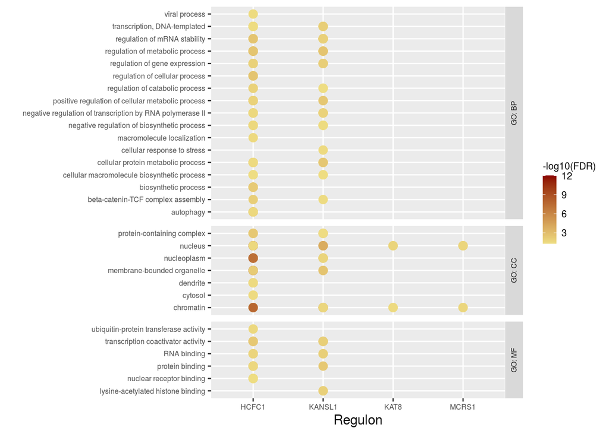

```r
# Bind together and format
regs_uk_GO <- dplyr::bind_rows(regs_uk_BP_GO, regs_uk_CC_GO, regs_uk_MF_GO)
regs_uk_GO <- dplyr::filter(regs_uk_GO, parent_term != "NA")
regs_uk_GO$go_type[regs_uk_GO$go_type=="BP"] <- "GO: BP"
regs_uk_GO$go_type[regs_uk_GO$go_type=="MF"] <- "GO: MF"
regs_uk_GO$go_type[regs_uk_GO$go_type=="CC"] <- "GO: CC"
# GO figure
ggplot2::ggplot(regs_uk_GO, aes(x = gene_list, y = parent_term)) +
  geom_point(size = 3, aes(colour = -log10(`FDR`))) +
  scale_color_continuous(low = "lightgoldenrod", high = "red4") +
  facet_grid(go_type ~., scales = "free", space = "free") +
  labs(x = "Regulon", y = "") +
  theme(
    axis.text = element_text(size = 6),
    strip.text.y = element_text(angle = 90, size = 6),
    legend.title = element_text(size = 8),
    legend.text = element_text(size = 8),
    legend.key.size = unit(4, "mm"))
```

### NSL regulon

The NSL regulon was analysed in a similar way to the individual regulons.

```r
# Run gprofiler
uk_3regs_gprof <- gprofiler2::gost(query = uk_3regs$Target_gene)
uk_3regs_gprof <- as.data.frame(uk_3regs_gprof$result)
uk_3regs_gprof <- as.data.frame(apply(uk_3regs_gprof, 2, as.character))
uk_3regs_gprof$FDR <- p.adjust(uk_3regs_gprof$p_value, method = "fdr")
# save
write.csv(uk_3regs_gprof, file.path(here::here("data", "ARACNe", "3regs_ukbec_gprof.csv")), row.names = FALSE)
```

```r
# Load
uk_3regs_gprof <- read.csv(file.path(here::here("data", "ARACNe", "3regs_ukbec_gprof.csv")))
# Add intersection ratio
uk_3regs_gprof <- uk_3regs_gprof %>%
  dplyr::mutate(Ratio = intersection_size/term_size)
```

First **molecular function**:

```r
# Molecular function
uk_3regs_MF <- uk_3regs_gprof %>%
  dplyr::filter(source == "GO:MF" & FDR <= 0.05) %>%
  dplyr::select(query, p_value, term_id, source, term_name, Ratio)
# Rename columns
names(uk_3regs_MF)[names(uk_3regs_MF)=="query"] <- "gene_list"
names(uk_3regs_MF)[names(uk_3regs_MF)=="term_id"] <- "go_id"
names(uk_3regs_MF)[names(uk_3regs_MF)=="source"] <- "go_type"
names(uk_3regs_MF)[names(uk_3regs_MF)=="term_name"] <- "go_term"
# FDR correct p values
uk_3regs_MF$p_value <- as.numeric(uk_3regs_MF$p_value)
uk_3regs_MF$FDR <- p.adjust(uk_3regs_MF$p_value, method="fdr")
# GO reduce all terms to parent terms
uk_3regs_MF$go_type <- "MF"
uk_3regs_MF_GO <- go_reduce(pathway_df = uk_3regs_MF, threshold = 0.7, scores = NULL)
```

Second **cellular component**

```r
# Cellular component
uk_3regs_CC <- uk_3regs_gprof %>%
  dplyr::filter(source == "GO:CC" & FDR <= 0.05) %>%
  dplyr::select(query, p_value, term_id, source, term_name, Ratio)
# Rename columns
names(uk_3regs_CC)[names(uk_3regs_CC)=="query"] <- "gene_list"
names(uk_3regs_CC)[names(uk_3regs_CC)=="term_id"] <- "go_id"
names(uk_3regs_CC)[names(uk_3regs_CC)=="source"] <- "go_type"
names(uk_3regs_CC)[names(uk_3regs_CC)=="term_name"] <- "go_term"
# FDR correct p values
uk_3regs_CC$p_value <- as.numeric(uk_3regs_CC$p_value)
uk_3regs_CC$FDR <- p.adjust(uk_3regs_CC$p_value, method="fdr")
# GO reduce all terms to parent terms
uk_3regs_CC$go_type <- "CC"
uk_3regs_CC_GO <- go_reduce(pathway_df = uk_3regs_CC, threshold = 0.7, scores = NULL)
```

Third **biological process**:

```r
# Biological process
uk_3regs_BP <- uk_3regs_gprof %>%
  dplyr::filter(source == "GO:BP" & FDR <= 0.05) %>%
  dplyr::select(query, p_value, term_id, source, term_name, Ratio)
# Rename columns
names(uk_3regs_BP)[names(uk_3regs_BP)=="query"] <- "gene_list"
names(uk_3regs_BP)[names(uk_3regs_BP)=="term_id"] <- "go_id"
names(uk_3regs_BP)[names(uk_3regs_BP)=="source"] <- "go_type"
names(uk_3regs_BP)[names(uk_3regs_BP)=="term_name"] <- "go_term"
# FDR correct p values
uk_3regs_BP$p_value <- as.numeric(uk_3regs_BP$p_value)
uk_3regs_BP$FDR <- p.adjust(uk_3regs_BP$p_value, method="fdr")
# GO reduce all terms to parent terms
uk_3regs_BP$go_type <- "BP"
uk_3regs_BP_GO <- go_reduce(pathway_df = uk_3regs_BP, threshold = 0.7, scores = NULL)
```

```r
# Bind together
uk_3regs_GO <- dplyr::bind_rows(uk_3regs_BP_GO, uk_3regs_CC_GO, uk_3regs_MF_GO)
# Format
uk_3regs_GO <- dplyr::filter(uk_3regs_GO, parent_term != "NA")
uk_3regs_GO$go_type[uk_3regs_GO$go_type=="BP"] <- "GO: BP"
uk_3regs_GO$go_type[uk_3regs_GO$go_type=="MF"] <- "GO: MF"
uk_3regs_GO$go_type[uk_3regs_GO$go_type=="CC"] <- "GO: CC"
# Add reduced terms count and mean intersection ratio
uk_3regs_GO_count <- uk_3regs_GO %>%
  dplyr::count(parent_term)
uk_3regs_GO <- uk_3regs_GO %>%
  dplyr::left_join(uk_3regs_GO_count, by = "parent_term") %>%
  dplyr::group_by(parent_term) %>%
  dplyr::mutate(mean_ratio = mean(Ratio))
```

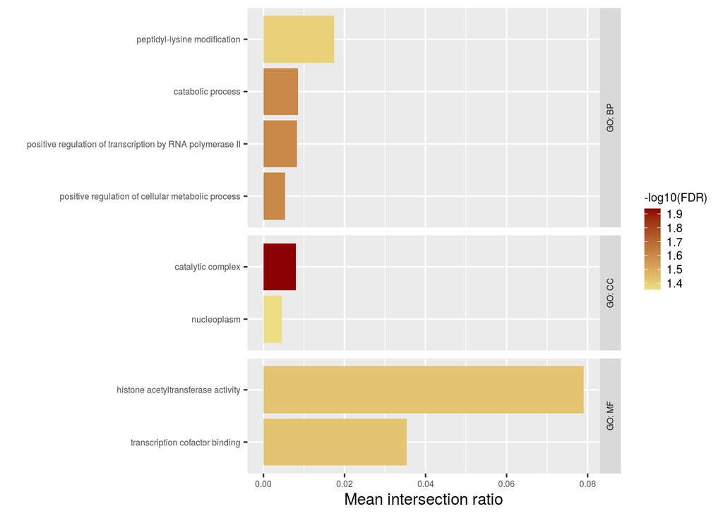

```r
# Plot on bar chart
uk_3regs_GO %>%
  dplyr::arrange(FDR) %>%
  dplyr::distinct(parent_term, .keep_all = TRUE) %>%
  ggplot2::ggplot(aes(x = mean_ratio,
                      y = reorder(parent_term, mean_ratio),
                      fill = -log10(`FDR`))) +
  geom_col() +
  scale_fill_gradient(high = "red4", low = "Lightgoldenrod") +
  facet_grid(go_type ~., scales = "free", space = "free") +
  labs(y = "", x = "Mean intersection ratio") +
  theme(
    axis.text = element_text(size = 6),
    strip.text.y = element_text(angle = 90, size = 6),
    legend.title = element_text(size = 8),
    legend.text = element_text(size = 8),
    legend.key.size = unit(4, "mm"))
```

## 5.4. KEGG/reactome term enrichment analysis

### Individual regulons

These terms were then compared to the list if PD-linked terms from [Bandres-Ciga et al., 2020](https://www.ncbi.nlm.nih.gov/pmc/articles/PMC8096770/). Firstly, as this list only contained terms from KEGG, Reactome and Pathway Interaction Database sources, the `gProfiler` results for each regulon were filtered for these sources and formatted.

```r
# Filter for KEGG and REACTOME terms
regs_uk_KGRE <- regs_uk_gprof %>%
  dplyr::filter(source %in% c("KEGG", "REAC"))
# Rename columns
names(regs_uk_KGRE)[names(regs_uk_KGRE)=="query"] <- "gene_list"
names(regs_uk_KGRE)[names(regs_uk_KGRE)=="term_id"] <- "go_id"
names(regs_uk_KGRE)[names(regs_uk_KGRE)=="source"] <- "go_type"
names(regs_uk_KGRE)[names(regs_uk_KGRE)=="term_name"] <- "go_term"
# FDR correct p values
regs_uk_KGRE$p_value <- as.numeric(regs_uk_KGRE$p_value)
regs_uk_KGRE$FDR <- p.adjust(regs_uk_KGRE$p_value, method="fdr")
# Format list for comparing terms
regs_uk_KGRE$col <- 1:nrow(regs_uk_KGRE)
regs_uk_KGRE_comp <- dplyr::select(regs_uk_KGRE, col, go_term)
```

The table of **PD-linked terms** was again checked for consistency with the regulon enriched terms. This was done using `tidystringdist`.

```r
# Combine lists
list_compare_uk <- dplyr::union(regs_uk_KGRE_comp$go_term, pd_r$Term)
list_compare_uk <- unique(list_compare_uk)
# Find similar but not identical matches
comparison_uk <- tidy_comb_all(list_compare_uk)
comparison_uk <- tidy_stringdist(comparison_uk)
comparison_uk <- dplyr::arrange(comparison_uk, V1)
comparison_uk_1 <- comparison_uk %>%
             dplyr::filter(osa < 10)
# Go through by eye- no terms were comparable so list can be filtered as is
```

The list of terms enriched for each NSL regulon was then filtered for the PD-linked terms.

```r
# Filter ARACNe list for paper list
all_terms_uk <- regs_uk_KGRE %>%
  dplyr::filter(go_term %in% pd_replication_tab1$Term) %>%
  dplyr::select(gene_list, go_term, p_value, FDR, go_type) %>%
  dplyr::arrange(go_term)
```

**No terms** were found to be common between the two lists.

### NSL regulon

The KEGG and reactome term enrichments for the NSL regulon was also compared to this PD-linked list of terms.

```r
# Filter for KEGG and REACTOME terms
uk_3regs_KGRE <- uk_3regs_gprof %>%
  dplyr::filter(source %in% c("KEGG", "REAC"))
# Rename columns
names(uk_3regs_KGRE)[names(uk_3regs_KGRE)=="query"] <- "gene_list"
names(uk_3regs_KGRE)[names(uk_3regs_KGRE)=="term_id"] <- "go_id"
names(uk_3regs_KGRE)[names(uk_3regs_KGRE)=="source"] <- "go_type"
names(uk_3regs_KGRE)[names(uk_3regs_KGRE)=="term_name"] <- "go_term"
# FDR correct p values
uk_3regs_KGRE$p_value <- as.numeric(uk_3regs_KGRE$p_value)
uk_3regs_KGRE$FDR <- p.adjust(uk_3regs_KGRE$p_value, method="fdr")
# Format list for comparing terms
uk_3regs_KGRE$col <- 1:nrow(uk_3regs_KGRE)
uk_3regs_KGRE_comp <- dplyr::select(uk_3regs_KGRE, col, go_term)
# Combine lists
list_compare_uk_3regs <- dplyr::union(uk_3regs_KGRE_comp$go_term, pd_r$Term)
list_compare_uk_3regs <- unique(list_compare_uk_3regs)
# Find similar but not identical matches
comparison_uk_3regs <- tidy_comb_all(list_compare_uk_3regs)
comparison_uk_3regs <- tidy_stringdist(comparison_uk_3regs)
comparison_uk_3regs <- dplyr::arrange(as.data.frame(comparison_uk_3regs), V1)
comparison_uk_3regs_1 <- comparison_uk_3regs %>%
             dplyr::filter(osa < 10)
# Go through by eye- no terms were comparable so list can be filtered as is
```

The list of terms enriched for each NSL regulon was then filtered for the PD-linked terms

```r
# Filter ARACNe list for paper list
all_terms_uk_3regs <- uk_3regs_KGRE %>%
  dplyr::filter(go_term %in% pd_replication_tab1$Term) %>%
  dplyr::arrange(go_term) %>%
  dplyr::mutate(Ratio = intersection_size/term_size)
```

**No terms** were found to be common between the two lists.